# Outlier Detection in Genetic Data

Mads Lindskou

# The 1000 Genomes Project Data

The outlier detection method (Lindskou, Svante Eriksen, and Tvedebrink 2019) arose from a problem in the forensic science community where it is of great interest to make statements about the geographical origin of a DNA sample. This is in general a very complicated matter. More over, when DNA markers are in linkage disequilibrium things get even more complicated. The 1000 Genomes Project set out to provide a comprehensive description of common human genetic variation by applying whole-genome sequencing to a diverse set of individuals from multiple populations (The 1000 Genomes Project Consortium 2015). In the **molic** package we include the final data from the project which includes $2504$ DNA profiles coming from five different continental regions; Europe (EUR), Africa (AFR), America (AMR), East Asia (EAS), South Asia (SAS). Each DNA profile is the compound of two rows in the data `tgp_dat`, one for each chromosome copy. This makes the outlier procedure slightly more complicated since we must fit a model to each copy and aggregate the information (but we shall see in a moment that it is not hard to do using the **molic** package).

## Setup and Data

```r
library(molic)
library(ess)   # for fit_components
library(dplyr)
set.seed(7)    # for reproducibility

## Data

# The components - here microhaplotypes
haps <- tgp_haps

# All the Europeans
eur <- tgp_dat %>%
  as_tibble() %>%
  filter(pop_meta == "EUR")

# Extracting the two databases for each copy of the chromosomes
eur_a <- eur %>%
  filter(grepl("a$", sample_name)) %>%
  select(-c(1:2))

eur_b <- eur %>%
  filter(grepl("b$", sample_name)) %>%
  select(-c(1:2))
```

We peak at data:

```r
print(eur, n_extra = 0)
```

```
## # A tibble: 1,006 x 304
##    sample_name pop_meta rs28529526 rs10134526 rs260694 rs11123719 rs11691107
##    <chr>       <chr>    <chr>      <chr>      <chr>    <chr>      <chr>
##  1 HG00096a    EUR      G          C          T        T          C
##  2 HG00097a    EUR      G          T          T        C          C
##  3 HG00099a    EUR      G          C          T        T          C
##  4 HG00100a    EUR      G          C          T        T          C
##  5 HG00101a    EUR      G          C          T        T          C
##  6 HG00102a    EUR      G          C          T        T          C
##  7 HG00103a    EUR      G          C          T        C          C
##  8 HG00105a    EUR      G          T          T        C          C
##  9 HG00106a    EUR      G          C          T        C          C
## 10 HG00107a    EUR      G          C          T        T          C
## # … with 996 more rows, and 297 more variables
```

We now fit the interaction graphs for each chromosome copy. We use `fit_components` since we know, that SNPs between haplotypes are independent. This also makes the procedure much faster.

```r
ga <- fit_components(eur_a, comp = haps, trace = FALSE)
gb <- fit_components(eur_b, comp = haps, trace = FALSE)
print(ga)
```

```
##  A Decomposable Graph With
##  -------------------------
##   Nodes: 302
##   Edges: 234 / 45451
##   Cliques: 161
##    - max: 4
##    - min: 1
##    - avg: 2.18
##   <gengraph, list>
##  -------------------------
```

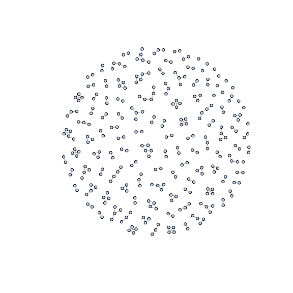

```r
plot(ga, vertex.size = 3, vertex.label = NA)
```

## Example 1 - Testing which observations within data are outliers

Fitting the model:

```r
# Only 500 simulations is used here to exeplify
# The default number of simulations is 10,000
m1 <- fit_outlier(eur_a, ga, nsim = 500) # consider using more cores (ncores argument)
m2 <- fit_outlier(eur_b, gb, nsim = 500) # consider using more cores (ncores argument)
m  <- fit_mixed_outlier(m1, m2)
```

Model information:

```r
print(m)
```

```
##
##  --------------------------------
##   Simulations: 500
##   Variables: 302
##   Observations: 503
##   Estimated mean: 482.36
##   Estimated variance: 345.85
##  --------------------------------
##   Critical value: 516.8367
##   Alpha: 0.05
##   <mixed_outlier, outlier, outlier_model, list>
##  --------------------------------
```

The distribution of the test statistic:

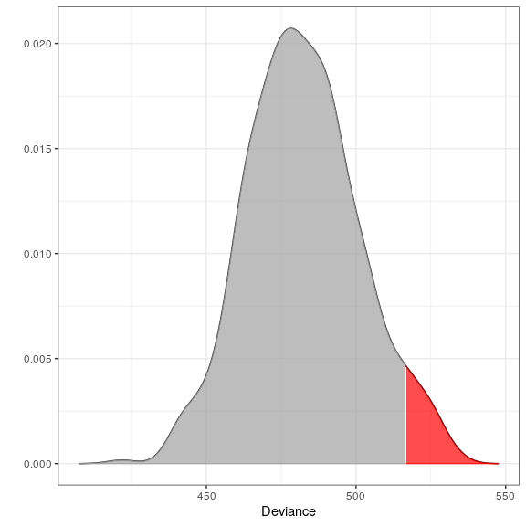

```r
plot(m)
```

Locating the outliers:

```r
outs <- outliers(m)
eur_a_outs <- eur_a[which(outs), ]
eur_b_outs <- eur_b[which(outs), ]
print(eur_a_outs, n_extra = 0)
```

```
## # A tibble: 19 x 302
##    rs28529526 rs10134526 rs260694 rs11123719 rs11691107 rs12469721 rs3101043
##    <chr>      <chr>      <chr>    <chr>      <chr>      <chr>      <chr>
##  1 G          C          T        T          C          A          C
##  2 G          C          T        C          C          T          T
##  3 G          C          T        T          C          T          T
##  4 G          C          T        C          C          A          T
##  5 G          T          T        T          C          A          T
##  6 G          C          T        C          C          T          T
##  7 G          T          T        T          C          A          C
##  8 G          C          T        C          C          A          C
##  9 G          C          T        T          C          A          C
## 10 G          C          T        C          C          T          C
## 11 G          C          T        T          C          T          C
## 12 G          C          T        C          C          A          T
## 13 G          C          T        T          C          T          T
## 14 G          C          T        T          T          T          T
## 15 G          C          T        T          C          A          C
## 16 G          C          T        T          C          T          T
## 17 G          C          T        T          C          T          C
## 18 G          T          T        T          C          T          C
## 19 G          T          T        T          C          A          T
## # … with 295 more variables
```

Retrieving the deviance test statistic for individual observations:

```r
x1 <- rbind(eur_a_outs[1, ], eur_b_outs[1, ])
x2 <- rbind(eur_a[1, ], eur_b[1, ])
dev1 <- deviance(m, x1) # falls within the critical region in the plot (the red area)
dev2 <- deviance(m, x2) # falls within the acceptable region in the plot

dev1
```

```
## [1] 537.9733
```

```r
dev2
```

```
## [1] 496.799
```

```r
# Retrieving the pvalues
pval(m, dev1)
```

```
## [1] 0
```

```r
pval(m, dev2)
```

```
## [1] 0.208
```

## Example 2 - Testing if a new observation is an outlier

Testing if an American is an outlier in Europe:

```r
amr <- tgp_dat %>%
  as_tibble() %>%
  filter(pop_meta == "AMR")

z1  <- amr %>%
  filter(grepl("a$", sample_name)) %>%
  select(unname(unlist(haps))) %>%
  slice(1) %>%
  unlist()

z2  <- amr %>%
  filter(grepl("b$", sample_name)) %>%
  select(unname(unlist(haps))) %>%
  slice(1) %>%
  unlist()

# Only 500 simulations is used here to exemplify
# The default number of simulations is 10,000
m3 <- fit_outlier(eur_a, ga, z1, nsim = 500) # consider using more cores (ncores argument)
m4 <- fit_outlier(eur_b, gb, z2, nsim = 500) # consider using more cores (ncores argument)
m5 <- fit_mixed_outlier(m3, m4)
print(m5)
```

```
##
##  --------------------------------
##   Simulations: 500
##   Variables: 302
##   Observations: 504
##   Estimated mean: 483.14
##   Estimated variance: 341.9
##  --------------------------------
##   Critical value: 516.6007
##   Deviance: 508.0499
##   P-value: 0.098
##   Alpha: 0.05
##   <mixed_outlier, novelty, outlier_model, list>
##  --------------------------------
```

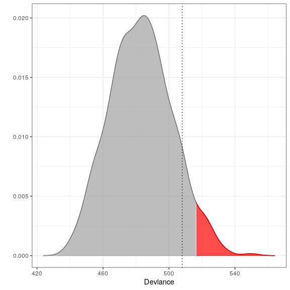

```r
plot(m5)
```

Thus, `z` does not deviate significantly from the Europe database. The red area depicts the $0.05$ significance level and the dotted line is the observed deviance of `z` (508.0498712). This is not a complete surprise, since Americans and Europeans have many similarities.

# References

Lindskou, Mads, Poul Svante Eriksen, and Torben Tvedebrink. 2019. “Outlier Detection in Contingency Tables Using Decomposable Graphical Models.” *Scandinavian Journal of Statistics*. Wiley Online Library. doi:10.1111/sjos.12407.

The 1000 Genomes Project Consortium. 2015. “A Global Reference for Human Genetic Variation.” *Nature* 526 (7571). Nature Publishing Group: 68. doi:10.1038/nature15393.